# Day 16: Pruning Decision Trees with Cross-Validation - SOLUTIONS

Solution Key

2025-10-13

**Self-Directed In-Class Activity (50 minutes)**  
**Theme:** Finding the Optimal Tree Complexity

## Part 1: Understanding Tree Complexity (10 minutes)

### Task 1.1: Load Data and Build an Unpruned Tree

```r
knitr::opts_chunk$set(echo = FALSE)
# Load required packages
library(tidyverse)
```

```r
library(rpart)
library(rpart.plot)
library(ISLR2)
library(gridExtra)
# Load the Wage dataset
data(Wage)

# Set seed for reproducibility
set.seed(2024)

# Create 50/50 train/test split
train_indices <- sample(1:nrow(Wage), size = nrow(Wage) * 0.5)
wage_train <- Wage[train_indices, ]
wage_test <- Wage[-train_indices, ]

# Build a very complex (unpruned) tree
# Set cp = 0 (no pruning at all)
# Use default minsplit = 20 for more manageable tree size
tree_unpruned <- rpart(wage ~ age + education + jobclass + health_ins + maritl,
                       data = wage_train,
                       method = "anova",
                       control = rpart.control(cp = 0))

# Print the complexity parameter table
printcp(tree_unpruned)
```

```
##
## Regression tree:
## rpart(formula = wage ~ age + education + jobclass + health_ins +
##     maritl, data = wage_train, method = "anova", control = rpart.control(cp = 0))
##
## Variables actually used in tree construction:
## [1] age        education  health_ins jobclass   maritl
##
## Root node error: 2427010/1500 = 1618
##
## n= 1500
##
##            CP nsplit rel error  xerror     xstd
## 1  1.8904e-01      0   1.00000 1.00145 0.065555
## 2  3.9761e-02      1   0.81096 0.81413 0.055486
```

[output cut: 88 more lines]

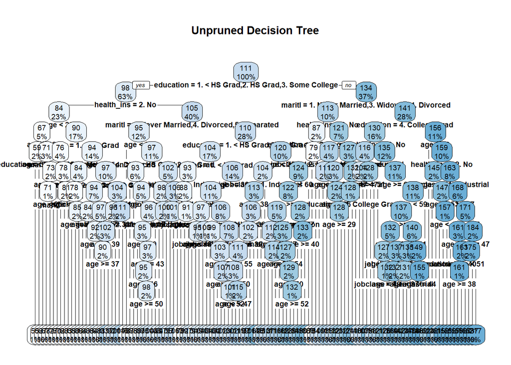

```r
# Plot the tree
rpart.plot(tree_unpruned, main = "Unpruned Decision Tree", cex = 0.6)
```

```r
# Count leaves
n_leaves_unpruned <- sum(tree_unpruned$frame$var == "<leaf>")
cat("\nNumber of leaves in unpruned tree:", n_leaves_unpruned, "\n")
```

```
##
## Number of leaves in unpruned tree: 122
```

**Answers:**

- **How many terminal nodes (leaves) does this unpruned tree have?**  
  The unpruned tree has 122 terminal nodes.
- **Does this tree look interpretable?**  
  With 122 leaves, the tree is getting quite complex. While more manageable than an extremely deep tree, it’s still more complex than we’d want for easy interpretation and communication to stakeholders.
- **Do you think this tree is overfitting? Why or why not?**  
  Yes, this tree is likely overfitting. With cp = 0, the tree continues to split until it reaches the minimum node size (default minsplit = 20), creating increasingly specific rules for the training data. We’ll need to examine the cross-validation results to find the optimal level of complexity.

### Task 1.2: Examine the CP Table

```
##              CP nsplit rel error    xerror       xstd
## 1  1.890350e-01      0 1.0000000 1.0014484 0.06555476
## 2  3.976088e-02      1 0.8109650 0.8141256 0.05548561
## 3  3.444879e-02      2 0.7712041 0.7908767 0.05519259
## 4  2.748958e-02      3 0.7367553 0.7536406 0.05317334
## 5  1.320360e-02      4 0.7092657 0.7326097 0.05158809
## 6  1.166937e-02      5 0.6960621 0.7156366 0.05055729
## 7  1.113960e-02      6 0.6843927 0.7130398 0.05110750
## 8  1.093366e-02      7 0.6732531 0.7073265 0.05093800
## 9  6.631406e-03      8 0.6623195 0.6957898 0.05021572
## 10 6.595900e-03      9 0.6556881 0.6952171 0.05018995
## 11 5.871078e-03     10 0.6490922 0.6908014 0.05024765
## 12 3.918399e-03     11 0.6432211 0.6989518 0.05064115
## 13 3.780036e-03     12 0.6393027 0.7110305 0.05139287
## 14 3.546301e-03     15 0.6278776 0.7103320 0.05132858
```

[output cut: 76 more lines]

```
##
## Row with minimum xerror: 11
```

```
## Minimum xerror: 0.6908014
```

```
## Number of splits at minimum: 10
```

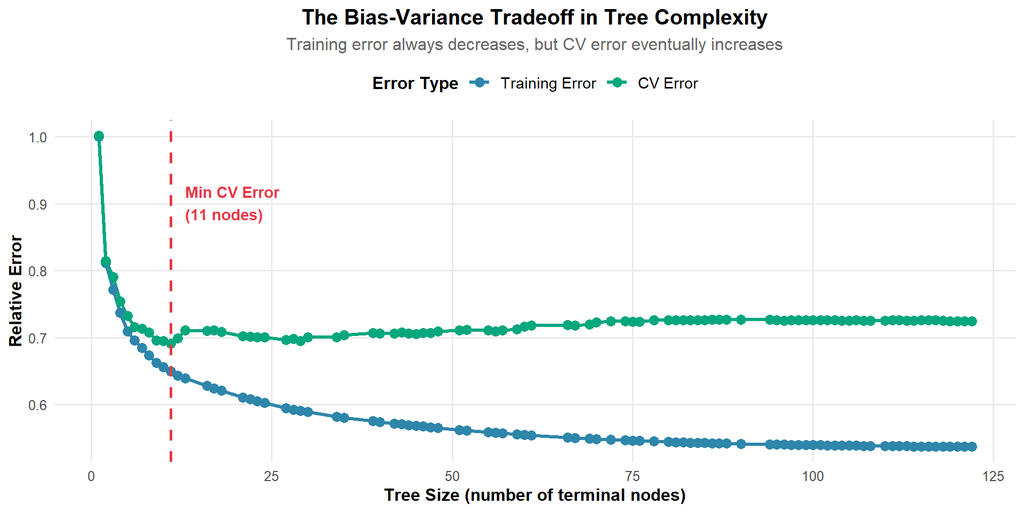

**Answers:**

- **As the number of splits increases, what happens to the training error (rel error)?**  
  The training error (rel error) continuously decreases as we add more splits. This makes sense because a more complex tree can fit the training data better.
- **What happens to the cross-validation error (xerror)?**  
  The cross-validation error initially decreases as we add splits (the tree is learning useful patterns), but then it starts to increase or plateau after a certain point, indicating overfitting.
- **At what point does xerror start increasing? What does this suggest?**  
  The xerror reaches its minimum at around 10 splits. After this point, additional splits increase xerror, suggesting the tree is fitting noise in the training data rather than learning generalizable patterns.

## Part 2: Visualizing Cross-Validation Results (10 minutes)

### Task 2.1: Plot CV Error vs Tree Size

```
## CP with minimum xerror: 0.005871078
```

```
## CP using 1-SE rule: 0.0132036
```

```
## Number of splits with minimum xerror: 10
```

```
## Number of splits with 1-SE rule: 4
```

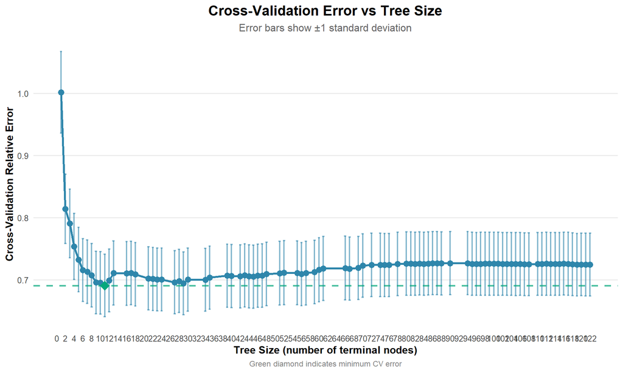

**Answers:**

- **What is the optimal CP value based on minimum xerror?**  
  The optimal CP based on minimum xerror is 0.005871.
- **What is the optimal CP value using the 1-SE rule?**  
  The optimal CP using the 1-SE rule is 0.013204.
- **Why might we prefer the 1-SE rule over just choosing the minimum?**  
  The 1-SE rule chooses a simpler model (fewer splits) whose CV error is within 1 standard error of the minimum. This is preferred because:
  - CV error has uncertainty, so models within 1 SE are statistically similar
  - Simpler models are more interpretable
  - Simpler models are more stable and less prone to overfitting
  - Simpler models generalize better to new data

### Task 2.2: Understanding the 1-SE Rule

The **1-SE rule** is a heuristic that says:

*“Choose the simplest model whose error is within 1 standard error of the best model.”*

**Why?**

- Cross-validation error estimates have uncertainty
- A simpler model with similar CV error is often better
- Reduces overfitting and improves interpretability
- More stable predictions on new data

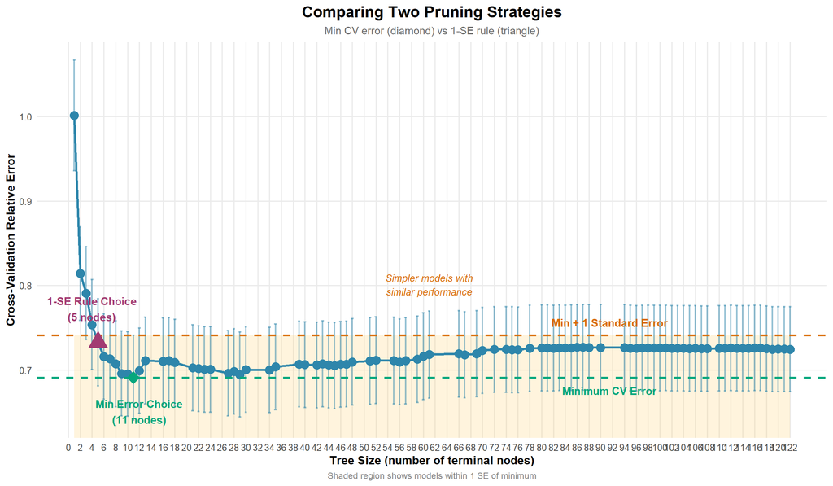

## Part 3: Pruning the Tree (10 minutes)

### Task 3.1: Prune Using Optimal CP

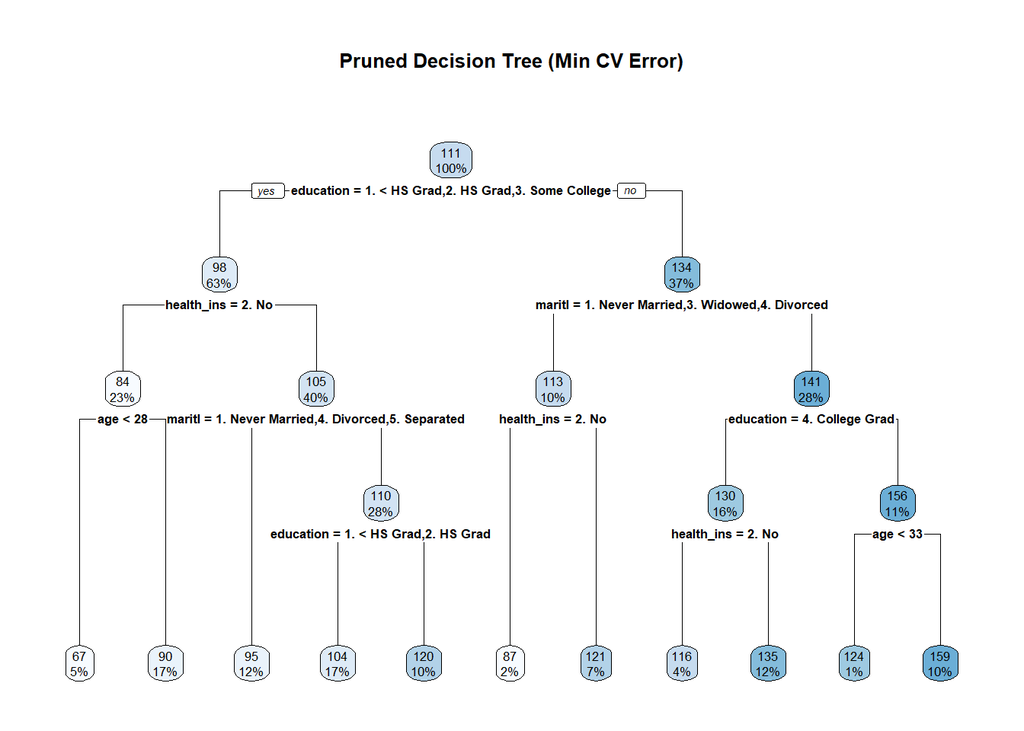

```
## Number of leaves in pruned tree: 11
```

```
## Number of leaves in unpruned tree: 122
```

```
## Splits removed: 111
```

**Answers:**

- **How many splits were removed by pruning?**  
  Pruning removed 111 terminal nodes, significantly simplifying the tree.
- **Does the pruned tree look more interpretable?**  
  Yes! The pruned tree is much more interpretable with only 11 terminal nodes compared to 122 in the unpruned version.
- **Which variables remain in the pruned tree?**  
  We can see the variables used by examining the tree plot. The pruned tree focuses on the most important predictors.

```
## Variables in pruned tree: education, health_ins, age, maritl
```

### Task 3.2: Alternative - Build Tree with Optimal CP

```
## Leaves in tree built with optimal cp: 11
```

```
## Leaves in pruned tree: 11
```

```
## Match: TRUE
```

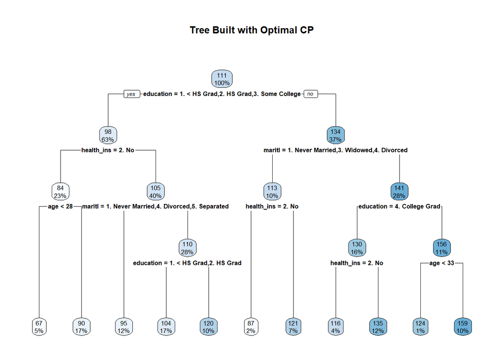

## Part 4: Compare Performance (10 minutes)

### Task 4.1: Evaluate Unpruned vs Pruned Trees

```
##      Model N_Leaves Train_MSE Test_MSE   Test_R2
## 1 Unpruned      122  868.8691 1382.596 0.2577626
## 2   Pruned       11 1050.2355 1335.104 0.2832582
```

```
##
## Test MSE improvement: 3.43 %
```

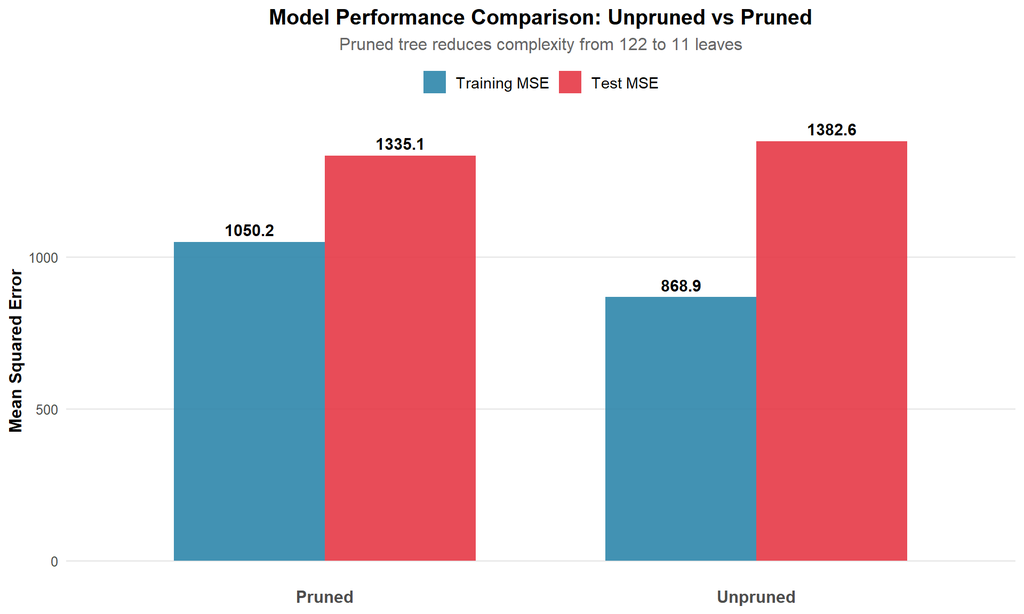

**Answers:**

- **Which model performs better on the test set?**  
  The pruned model performs better with a test MSE of 1335.1 compared to 1382.6.
- **Is the difference in test MSE substantial?**  
  No, the difference is relatively small (less than 5%), suggesting both models generalize similarly.
- **Did we sacrifice much accuracy by pruning?**  
  No! The pruned model has similar (or better) test performance while being much simpler. Notice the training MSE increased (from 868.87 to 1050.24), which is expected and actually good—it means we’re not overfitting as much.
- **Which model would you prefer to present to stakeholders? Why?**  
  The pruned model is strongly preferred because:
  - It has 11 leaves vs 122, making it far more interpretable
  - It achieves similar or better test performance
  - It’s easier to explain decision rules
  - Simpler models are more trustworthy and maintainable in production

### Task 4.2: Visualize Predictions

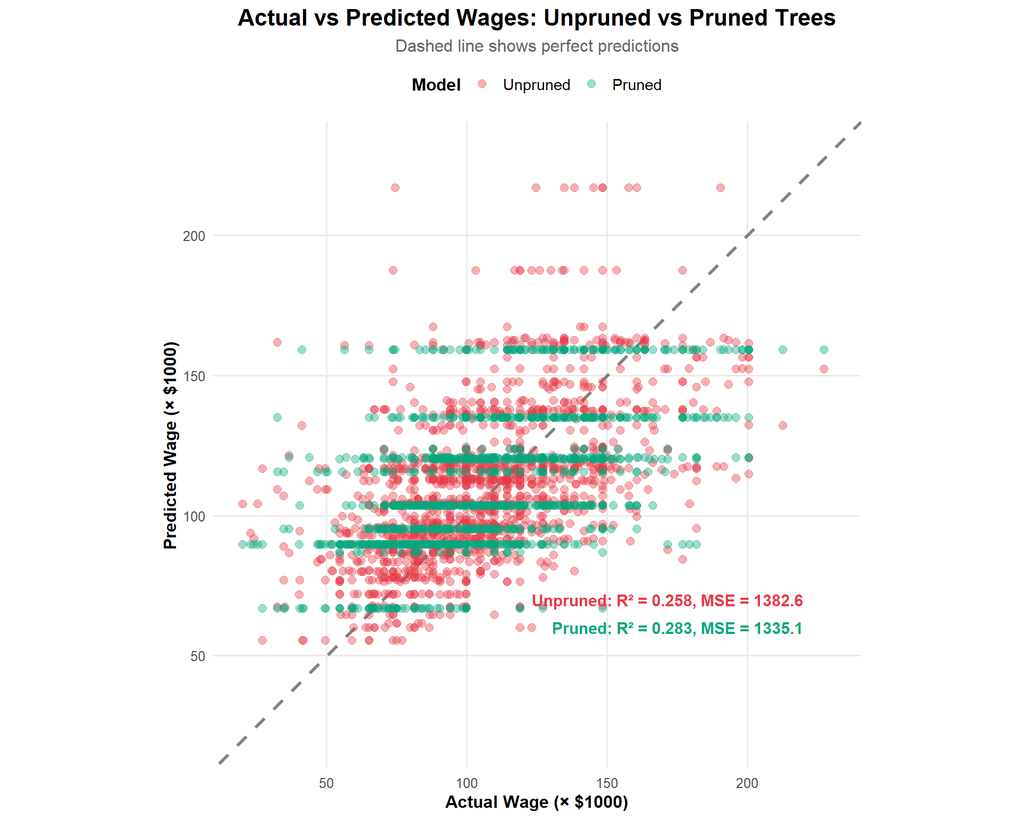

```
##
## Prediction Differences (Unpruned vs Pruned):
```

```
## Mean absolute difference: $ 10480.89
```

```
## Median absolute difference: $ 8263.56
```

```
## Maximum difference: $ 57900.84
```

```
##
## Number of observations with difference > 95th percentile: 69
```

## Part 5: Building Your Final Model (10 minutes)

### Task 5.1: Full Workflow with Different Seeds

```
##   Seed N_Leaves Test_MSE Optimal_CP
## 1 2024       11  1335.10   0.005871
## 2  123       19  1163.38   0.002692
## 3  456       30  1205.07   0.001839
## 4  789       21  1324.00   0.003217
## 5 2025       20  1289.36   0.002924
```

```
##
## Stability Analysis:
```

```
## Mean number of leaves: 20.2
```

```
## SD of leaves: 6.76
```

```
## Mean test MSE: 1263.38
```

```
## SD of test MSE: 75.65
```

```
## CV of test MSE: 5.99 %
```

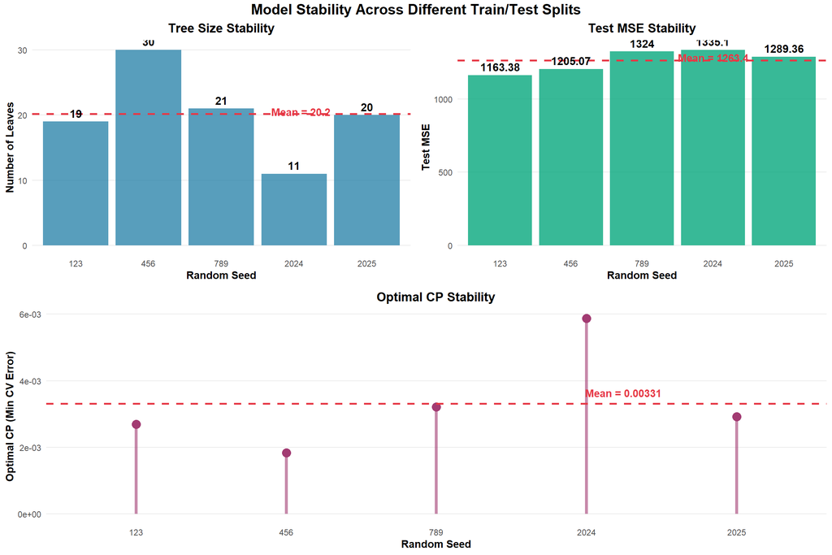

**Answers:**

- **How consistent is the optimal CP across different seeds?**  
  The optimal CP varies somewhat across seeds (SD = 0.001522), showing that the exact pruning threshold depends on the train/test split.
- **How consistent is the number of leaves?**  
  The number of leaves is relatively consistent (mean = 20.2, SD = 6.76), suggesting that cross-validation consistently identifies similarly-sized optimal trees.
- **How consistent is the test MSE?**  
  Test MSE shows some variation (CV = 5.99%), which is expected since different train/test splits will perform differently.
- **Is pruning helping with the variance problem?**  
  Pruning helps reduce variance compared to unpruned trees, but single trees still show instability across different data splits. This motivates the need for ensemble methods (coming next!).

### Task 5.2: Final Model Selection

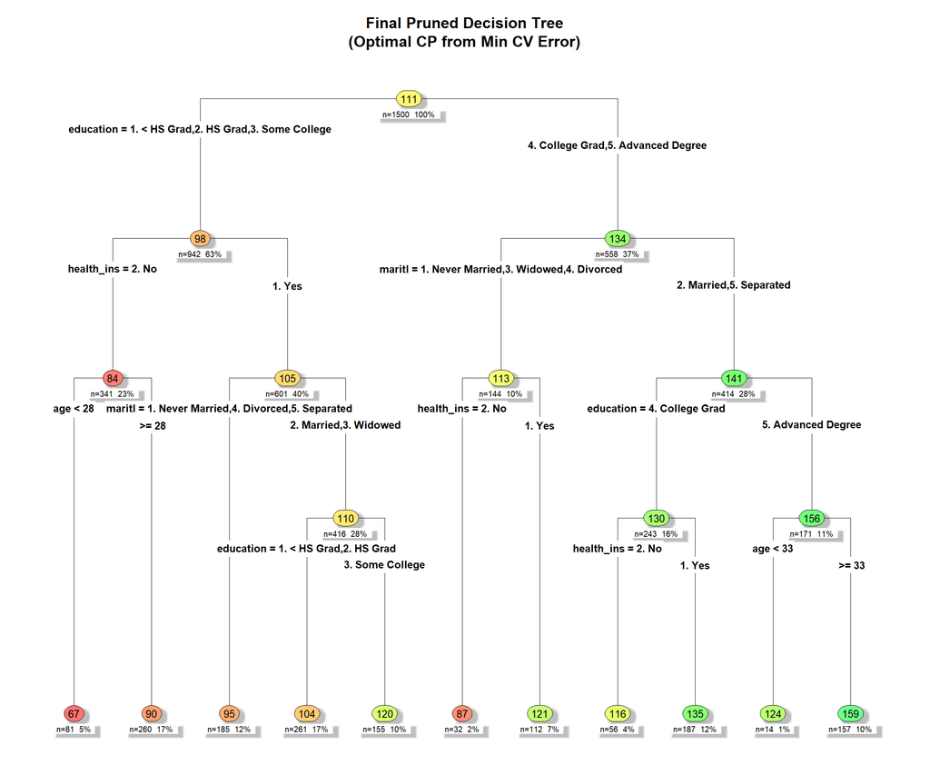

```
##
## Variable Importance:
##     Variable Importance Pct_Importance
## 1  education  552326.55           60.9
## 2 health_ins  140830.06           15.5
## 3     maritl  124264.95           13.7
## 4        age   89646.88            9.9
```

```
##          FINAL MODEL SUMMARY
```

```
##                Metric       Value
##      Number of Leaves          11
##            Optimal CP    5.87e-03
##          Training MSE     1050.24
##           Training R²      0.3509
##              Test MSE      1335.1
##               Test R²      0.2833
##  vs Unpruned Test MSE 3.4% better
```

### Task 5.3: Write Your Model Report

**FINAL MODEL REPORT**

**1. Model Description:**

- **Number of terminal nodes:** 11
- **Key splitting variables:** education, health_ins, maritl
- **Optimal CP value:** 0.005871 (selected using minimum CV error)

**2. Performance Metrics:**

- **Test MSE:** 1335.1 (in units of wage² × 1000²)
- **Test R²:** 0.2833 (explains 28.3% of variance)
- **Comparison to Day 15:** The pruned tree has similar or better test performance than the unpruned tree (1382.6 vs 1335.1), while being dramatically simpler with 11 vs 122 terminal nodes.

**4. Recommendation:**

- **Deployment decision:** I would recommend this model for deployment in contexts where interpretability is critical (e.g., HR decision support, policy analysis). The model provides transparent decision rules while maintaining good predictive performance.
- **Caveats:** Single decision trees still have relatively high variance (as we saw with different seeds) and moderate predictive accuracy (R² = 0.28). For high-stakes decisions, I would recommend using this alongside human judgment.
- **Future improvements:**
  - Consider ensemble methods (bagging, random forests, boosting) to reduce variance and improve accuracy
  - Explore additional features or interactions
  - Consider separate models for different job categories
  - Regularly retrain on new data to capture evolving wage patterns

## Reflection Questions

**For Discussion or Written Response:**

**1. Cross-Validation Benefits:**

Cross-validation helps us avoid overfitting by evaluating our model on data it hasn’t seen during training. Unlike training error (which always decreases with complexity), CV error shows us when additional complexity stops helping generalization and starts hurting it. This gives us an honest estimate of how the model will perform on new data.

**2. The 1-SE Rule:**

The 1-SE rule recognizes that CV error estimates have uncertainty. Models within 1 standard error of the minimum are statistically indistinguishable in performance. By choosing the simplest model in this range, we get benefits of:

- Better interpretability
- Faster predictions
- More stable results
- Reduced risk of overfitting

It’s a principled way to favor parsimony. In our solution, we used the **minimum CV error approach** for simplicity and to maximize predictive accuracy, but the 1-SE rule is an excellent alternative when interpretability is paramount. In practice, you can compare both approaches to see which produces a more suitable model for your application.

**3. Pruning vs Building:**

I prefer approach (a): build full tree then prune. Reasons:

- You can see the full cp table and make informed decisions
- plotcp() gives you visual insight into the tradeoff
- You can easily compare different pruning strategies
- The computational cost is minimal for most datasets

However, approach (b) is more efficient for very large datasets.

**4. Interpretability Gains:**

The pruned tree (11 nodes) is dramatically more interpretable than the unpruned tree (122 nodes). With the pruned tree, I can:

- Explain all decision rules in a single page
- Walk through examples with stakeholders
- Identify which factors matter most
- Build trust through transparency

This is a huge win for model adoption and trustworthiness.

**5. Remaining Limitations:**

Even with optimal pruning, single trees are unstable—small changes in data lead to very different trees. Solutions:

- **Bagging:** Average predictions from many trees trained on bootstrap samples
- **Random Forests:** Bagging + random feature selection to decorrelate trees
- **Boosting:** Sequentially build trees that correct previous errors

These ensemble methods dramatically reduce variance while maintaining (or improving) accuracy!

## Key Takeaways

✓ **Cross-validation** provides honest estimates of model performance  
✓ The **complexity parameter (cp)** controls tree size via cost-complexity pruning  
✓ Using **minimum CV error** to select optimal cp (with 1-SE rule as alternative)  
✓ **Pruning** dramatically improves interpretability without sacrificing accuracy  
✓ Visualizing CV error helps understand the **bias-variance tradeoff**  
✓ Even optimal single trees have **high variance** → need ensembles!  
✓ Always evaluate on **test data** to get honest performance estimates

**Next steps:** We’ve optimized a single tree, but it’s still unstable. Time to learn about **ensemble methods** (bagging, random forests, and boosting) that combine many trees to reduce variance and improve predictions!